# E-commerce Exploratory Analytics & Dashboard

Student ID: 249611072

2024-11-26

# 1 Assignment Overview

## 1.1 Background

With the rise of e-commerce, understanding customer behavior and purchasing patterns is vital for online businesses. Utilizing transactional data can provide actionable insights, helping to optimize sales strategies, improve customer experiences, and maximize revenue. Your primary objective is to assist an online retailer by analyzing their transaction data to uncover sales trends, customer segmentation, and potential areas of improvement.

## 1.2 Data Insights

The dataset captures transactions from December 2010 to December 2011 from a UK-based online retailer. Fields include:

- `InvoiceNo` - Invoice number - a 6-digit integral number uniquely assigned to each transaction. If this code starts with letter ‘c’, it indicates a cancellation.
- `StockCode` - a 5-digit integral number uniquely assigned to each distinct product
- `Description` - product name
- `Quantity` - the quantities of each product (item) per transaction
- `InvoiceDate` - the day and time when each transaction was generated
- `UnitPrice` - product price per unit
- `CustomerID` - a 5-digit integral number uniquely assigned to each customer
- `Country` - the name of the country where each customer resides

For more details about the dataset, refer to the [UCI Machine Learning Repository](https://archive.ics.uci.edu/ml/datasets/Online+Retail).

## 1.3 Part 1: Data Exploration with R (60% of total marks)

### 1.3.1 Task

Based on the dataset, determine:

1. What are the most popular products and how do their sales vary over time?
2. Can we segment customers based on their purchasing behavior?
3. Are there specific countries that contribute more to sales or have unique buying patterns?
4. (Bonus) How do cancellations impact overall sales trends?

**Reflection**: Beyond the questions above, take a moment to examine the dataset critically.

- Are there any other interesting patterns or anomalies you notice?
- What additional questions or analyses come to mind that could be valuable for the retailer?
- How might external factors, not present in the dataset, influence the trends you’ve observed?

Document your process, findings, and reflections in the current *R Notebook* - just use the space below this assignment instructions. Be compact in your descriptive and reflective answers!

### 1.3.2 Submission Requirements

- The RMD file containing all answers and relevant code.
- An HTML version of the notebook, knitted from the RMD.

**Note**: Ensure your report is: - Structured for easy navigation. - Includes clear visualizations with apt labels and annotations. - Provides short, compact answers to the exploratory questions, also documenting key steps. - Contains efficient and easily executable R code, preferably using `%>%` pipes for streamlined data manipulation.

## 1.4 Part 2: Tableau Dashboard (40% of total marks)

### 1.4.1 Task

Using insights from your R analysis, design a user-friendly, interactive dashboard in Tableau Desktop. Focus on showcasing significant findings related to sales trends and customer behaviors. Your target audience is the CEO of the online retail store - a non-tech-savvy individual keen on understanding broad trends, customer insights, and avenues for growth.

1. **Storyboarding**: Prior to Tableau, sketch a dashboard storyboard, snapshot or photograph it for the submission.
2. **Dashboard Creation in Tableau**: Transform your R insights into a user-centric Tableau dashboard. Highlight crucial trends and customer behaviors.

### 1.4.2 Guidelines

- Prioritize clarity and ease of navigation.
- Utilize filters and design elements for an intuitive user experience.
- Add descriptions and headers to guide users through your dashboard.

### 1.4.3 Submission Requirement

- Submit the image of your storybaord sketch;
- Submit the Tableau Packaged Workbook (TWBX) file, including all worksheets and the final dashboard.

**Caution**: Always export as a *Tableau Packaged Workbook (TWBX)*. Exporting as a *Tableau Workbook (TWB)* might omit important data operations, making your dashboard potentially unreadable.

# 2 Commence Your Assignment Here

## 2.1 Data Import & Preliminaries

# 3 Loading required libraries

```r
library(dplyr)
```

```r
library(ggplot2)
library(lubridate)
library(tidyr)
library(readr)
library(stringr)

data <- read_csv("Online Retail.csv")
## Data Diagnostic

# Since description column has multiple unnecessary entries, we are cleaning the data


cleaned_data <- data %>%
  filter(
    !is.na(Description),                              # Remove NA values
    str_trim(Description) != "",                     # Remove blank descriptions
    !str_detect(Description, "TEST|SAMPLE|WRONG"),   # Remove descriptions with keywords
    !str_detect(Description, "^[0-9]+$"),            #Remove numeric-only descriptions
    !str_detect(Description, "[^A-Za-z0-9 ]")        #Remove descriptions with special characters
  )


# View unique descriptions after cleaning
unique_cleaned_descriptions <- cleaned_data %>%
  distinct(Description) %>%
  pull(Description)

# Display the first 20 cleaned descriptions
print(head(unique_cleaned_descriptions, 20))
```

```
##  [1] "WHITE METAL LANTERN"                 "CREAM CUPID HEARTS COAT HANGER"
##  [3] "KNITTED UNION FLAG HOT WATER BOTTLE" "SET 7 BABUSHKA NESTING BOXES"
##  [5] "HAND WARMER UNION JACK"              "HAND WARMER RED POLKA DOT"
##  [7] "ASSORTED COLOUR BIRD ORNAMENT"       "FELTCRAFT PRINCESS CHARLOTTE DOLL"
##  [9] "IVORY KNITTED MUG COSY"              "BOX OF 6 ASSORTED COLOUR TEASPOONS"
## [11] "BOX OF VINTAGE JIGSAW BLOCKS"        "BOX OF VINTAGE ALPHABET BLOCKS"
## [13] "HOME BUILDING BLOCK WORD"            "LOVE BUILDING BLOCK WORD"
## [15] "RECIPE BOX WITH METAL HEART"         "DOORMAT NEW ENGLAND"
## [17] "JAM MAKING SET WITH JARS"            "RED COAT RACK PARIS FASHION"
## [19] "YELLOW COAT RACK PARIS FASHION"      "BLUE COAT RACK PARIS FASHION"
```

```r
# Remove rows where the Description column contains "?"
cleaned_data <- data %>%
  filter(!str_detect(Description, "\\?"))

# Verify no descriptions with "?" exist
any(str_detect(cleaned_data$Description, "\\?"))
```

```
## [1] FALSE
```

```r
# Inspect rows where StockCode has more than 5 characters
invalid_stockcodes <- data %>%
  filter(nchar(as.character(StockCode)) > 5)

print(head(invalid_stockcodes))
```

```
## # A tibble: 6 × 8
##   InvoiceNo StockCode Description      Quantity InvoiceDate UnitPrice CustomerID
##   <chr>     <chr>     <chr>               <dbl> <chr>           <dbl>      <dbl>
## 1 536365    85123A    WHITE HANGING H…        6 01/12/2010…      2.55      17850
## 2 536365    84406B    CREAM CUPID HEA…        8 01/12/2010…      2.75      17850
## 3 536365    84029G    KNITTED UNION F…        6 01/12/2010…      3.39      17850
## 4 536365    84029E    RED WOOLLY HOTT…        6 01/12/2010…      3.39      17850
## 5 536373    85123A    WHITE HANGING H…        6 01/12/2010…      2.55      17850
## 6 536373    84406B    CREAM CUPID HEA…        8 01/12/2010…      2.75      17850
## # ℹ 1 more variable: Country <chr>
```

```r
# Filter out rows with StockCode longer than 5 characters
cleaned_data <- data %>%
  filter(nchar(as.character(StockCode)) <= 5)

# Verify no StockCodes longer than 5 characters remain
any(nchar(as.character(cleaned_data$StockCode)) > 5)
```

```
## [1] FALSE
```

```r
write.csv(cleaned_data, "Cleaned_Online_Retail.csv", row.names = FALSE)


data <- read_csv("Cleaned_Online_Retail.csv")
# Inspect rows with "adjust bad debt"
bad_debt_entry <- data %>%
  filter(Description == "adjust bad debt")

print(bad_debt_entry)
```

```
## # A tibble: 0 × 8
## # ℹ 8 variables: InvoiceNo <chr>, StockCode <chr>, Description <chr>,
## #   Quantity <dbl>, InvoiceDate <chr>, UnitPrice <dbl>, CustomerID <dbl>,
## #   Country <chr>
```

```r
# Remove rows with "adjust bad debt"
cleaned_data <- data %>%
  filter(Description != "adjust bad debt")

# Filter rows where UnitPrice is unreasonably negative
cleaned_data <- data %>%
  filter(UnitPrice > -10000)  # Adjust threshold as needed

# Verify the removal
any(cleaned_data$Description == "adjust bad debt")
```

```
## [1] NA
```

```r
## In-depth Exploratory Data Analysis


# 1. What are the most popular products and how do their sales vary over time?
# Top 10 products based on their quantity sold
top_products <- data %>%
  group_by(Description) %>%     #
  summarise(TotalQuantity = sum(Quantity, na.rm = TRUE)) %>%
  arrange(desc(TotalQuantity)) %>%
  slice(1:10)


print(top_products)
```

```
## # A tibble: 10 × 2
##    Description                        TotalQuantity
##    <chr>                                      <dbl>
##  1 WORLD WAR 2 GLIDERS ASSTD DESIGNS          53847
##  2 ASSORTED COLOUR BIRD ORNAMENT              36381
##  3 POPCORN HOLDER                             36334
##  4 PACK OF 72 RETROSPOT CAKE CASES            36039
##  5 RABBIT NIGHT LIGHT                         30680
##  6 MINI PAINT SET VINTAGE                     26437
##  7 PACK OF 12 LONDON TISSUES                  26315
##  8 PACK OF 60 PINK PAISLEY CAKE CASES         24753
##  9 VICTORIAN GLASS HANGING T-LIGHT            23854
## 10 ASSORTED COLOURS SILK FAN                  23082
```

```r
# OBSERVATIONS:
# Top 10 best selling products are as follows:
# 1. WORLD WAR 2 GLIDERS ASSTD DESIGNS
# 2. ASSORTED COLOUR BIRD ORNAMENT
# 3. POPCORN HOLDER
# 4. PACK OF 72 RETROSPOT CAKE CASES
# 5. RABBIT NIGHT LIGHT
# 6. MINI PAINT SET VINTAGE
# 7. PACK OF 12 LONDON TISSUES
# 8. PACK OF 60 PINK PAISLEY CAKE CASES
# 9. VICTORIAN GLASS HANGING T-LIGHT
# 10. ASSORTED COLOURS SILK FAN


# Getting sales over time
#Convert InvoiceDate to Date format

data <- data %>%
  mutate(InvoiceDate = as.Date(InvoiceDate, format = "%m/%d/%Y"))

data
```

```
## # A tibble: 489,881 × 8
##    InvoiceNo StockCode Description     Quantity InvoiceDate UnitPrice CustomerID
##    <chr>     <chr>     <chr>              <dbl> <date>          <dbl>      <dbl>
##  1 536365    71053     WHITE METAL LA…        6 2010-01-12       3.39      17850
##  2 536365    22752     SET 7 BABUSHKA…        2 2010-01-12       7.65      17850
##  3 536365    21730     GLASS STAR FRO…        6 2010-01-12       4.25      17850
##  4 536366    22633     HAND WARMER UN…        6 2010-01-12       1.85      17850
##  5 536366    22632     HAND WARMER RE…        6 2010-01-12       1.85      17850
##  6 536367    84879     ASSORTED COLOU…       32 2010-01-12       1.69      13047
##  7 536367    22745     POPPY'S PLAYHO…        6 2010-01-12       2.1       13047
##  8 536367    22748     POPPY'S PLAYHO…        6 2010-01-12       2.1       13047
##  9 536367    22749     FELTCRAFT PRIN…        8 2010-01-12       3.75      13047
## 10 536367    22310     IVORY KNITTED …        6 2010-01-12       1.65      13047
## # ℹ 489,871 more rows
## # ℹ 1 more variable: Country <chr>
```

```r
# sales over time

sales_over_time <- data %>%
  filter(Description %in% top_products$Description) %>%
  group_by(InvoiceDate, Description) %>%
  summarise(DailyQuantity = sum(Quantity, na.rm = TRUE)) #summarised data
print(sales_over_time)
```

```
## # A tibble: 992 × 3
## # Groups:   InvoiceDate [128]
##    InvoiceDate Description                        DailyQuantity
##    <date>      <chr>                                      <dbl>
##  1 2010-01-12  ASSORTED COLOUR BIRD ORNAMENT                224
##  2 2010-01-12  MINI PAINT SET VINTAGE                       108
##  3 2010-01-12  PACK OF 12 LONDON TISSUES                     40
##  4 2010-01-12  PACK OF 60 PINK PAISLEY CAKE CASES           122
##  5 2010-01-12  PACK OF 72 RETROSPOT CAKE CASES              241
##  6 2010-01-12  VICTORIAN GLASS HANGING T-LIGHT               69
##  7 2010-02-12  ASSORTED COLOUR BIRD ORNAMENT                503
##  8 2010-02-12  ASSORTED COLOURS SILK FAN                     48
##  9 2010-02-12  MINI PAINT SET VINTAGE                       288
## 10 2010-02-12  PACK OF 12 LONDON TISSUES                    616
## # ℹ 982 more rows
```

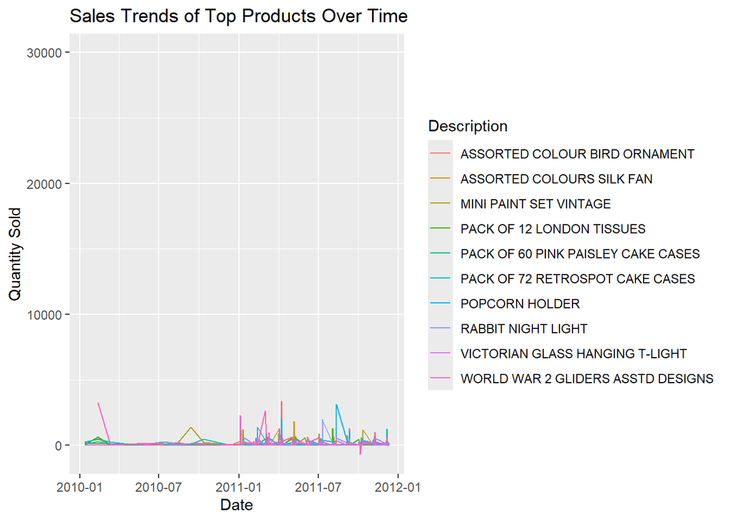

```r
#Line chart to show sales over time
ggplot(sales_over_time, aes(x = InvoiceDate, y = DailyQuantity, color = Description)) +
  geom_line() +
  labs(title = "Sales Trends of Top Products Over Time", x = "Date", y = "Quantity Sold")
```

```r
# 2. Can we segment customers based on their purchasing behavior?

#We can segment users based on multiple factors such as:
#a. Product-based segmentation: customers who buy a particular product more often

product_affinity <- data %>%
  group_by(CustomerID, Description) %>%
  summarise(TotalQuantity = sum(Quantity, na.rm = TRUE)) %>%
  top_n(1, TotalQuantity)
print(product_affinity)
```

```
## # A tibble: 7,355 × 3
## # Groups:   CustomerID [4,353]
##    CustomerID Description                        TotalQuantity
##         <dbl> <chr>                                      <dbl>
##  1      12346 MEDIUM CERAMIC TOP STORAGE JAR                 0
##  2      12347 ICE CREAM SUNDAE LIP GLOSS                   240
##  3      12348 DOUGHNUT LIP GLOSS                           200
##  4      12349 STRAWBERRY CERAMIC TRINKET POT                36
##  5      12349 SWEETHEART CERAMIC TRINKET BOX                36
##  6      12350 TEA BAG PLATE RED RETROSPOT                   24
##  7      12352 PINK HEART SHAPE EGG FRYING PAN               24
##  8      12353 MINI CAKE STAND WITH HANGING CAKES             8
##  9      12354 BLUE POLKADOT CUP                             32
## 10      12354 BLUE POLKADOT PLATE                           32
## # ℹ 7,345 more rows
```

```r
#b. Time based segmentation: customers who buy on a particular day of the week

data <- data %>%
  mutate(
    Hour = hour(as.POSIXct(InvoiceDate)),
    DayOfWeek = wday(as.POSIXct(InvoiceDate), label = TRUE)
  )

time_segments <- data %>%
  group_by(CustomerID, DayOfWeek) %>%
  summarise(TotalSpent = sum(Quantity * UnitPrice, na.rm = TRUE))
print(time_segments)
```

```
## # A tibble: 9,828 × 3
## # Groups:   CustomerID [4,353]
##    CustomerID DayOfWeek TotalSpent
##         <dbl> <ord>          <dbl>
##  1      12346 <NA>              0
##  2      12347 Mon            1137.
##  3      12347 Tue             990.
##  4      12347 <NA>           1527.
##  5      12348 Wed             367
##  6      12348 <NA>           1430.
##  7      12349 <NA>           1672.
##  8      12350 Wed             298
##  9      12352 Mon             144.
## 10      12352 Fri             312.
## # ℹ 9,818 more rows
```

```r
# Convert InvoiceDate to a Date object
data <- data %>%
  mutate(InvoiceDate = as.Date(InvoiceDate))

# Extract year from InvoiceDate
data <- data %>%
  mutate(Year = year(InvoiceDate))


#c. Customers who shopped in both 2010 and 2011
customers_2010_2011 <- data %>%
  filter(Year %in% c(2010, 2011)) %>%
  group_by(CustomerID) %>%
  summarise(Years = list(unique(Year))) %>%
  filter(all(c(2010, 2011) %in% Years)) %>%
  pull(CustomerID)

# Filter data for only those customers
data_2010_2011 <- data %>%
  filter(CustomerID %in% customers_2010_2011)

customers_2010_2011
```

```
##    [1] 12347 12348 12350 12352 12355 12356 12357 12358 12359 12362 12363 12364
##   [13] 12367 12370 12371 12372 12373 12375 12378 12379 12380 12381 12383 12384
##   [25] 12386 12388 12393 12394 12395 12397 12399 12401 12406 12407 12408 12409
##   [37] 12410 12413 12414 12415 12417 12420 12422 12423 12427 12428 12429 12431
##   [49] 12433 12434 12436 12437 12441 12442 12444 12447 12449 12450 12451 12455
##   [61] 12457 12461 12462 12463 12464 12465 12468 12471 12472 12473 12474 12476
##   [73] 12477 12478 12479 12480 12481 12483 12484 12489 12490 12491 12492 12494
##   [85] 12500 12501 12502 12503 12504 12505 12507 12508 12512 12516 12517 12518
##   [97] 12519 12520 12523 12524 12526 12528 12530 12532 12534 12535 12536 12538
##  [109] 12539 12540 12541 12544 12546 12547 12552 12553 12556 12557 12558 12559
##  [121] 12560 12561 12562 12565 12567 12569 12571 12572 12576 12577 12578 12580
##  [133] 12583 12584 12585 12586 12587 12589 12590 12592 12593 12594 12596 12597
##  [145] 12598 12599 12600 12601 12602 12605 12607 12609 12610 12613 12614 12615
##  [157] 12616 12617 12619 12621 12623 12625 12626 12627 12628 12633 12635 12637
##  [169] 12638 12643 12644 12645 12646 12647 12648 12649 12650 12651 12652 12654
```

[output cut: 244 more lines]

```r
data_2010_2011
```

```
## # A tibble: 448,855 × 11
##    InvoiceNo StockCode Description     Quantity InvoiceDate UnitPrice CustomerID
##    <chr>     <chr>     <chr>              <dbl> <date>          <dbl>      <dbl>
##  1 536365    71053     WHITE METAL LA…        6 2010-01-12       3.39      17850
##  2 536365    22752     SET 7 BABUSHKA…        2 2010-01-12       7.65      17850
##  3 536365    21730     GLASS STAR FRO…        6 2010-01-12       4.25      17850
##  4 536366    22633     HAND WARMER UN…        6 2010-01-12       1.85      17850
##  5 536366    22632     HAND WARMER RE…        6 2010-01-12       1.85      17850
##  6 536367    84879     ASSORTED COLOU…       32 2010-01-12       1.69      13047
##  7 536367    22745     POPPY'S PLAYHO…        6 2010-01-12       2.1       13047
##  8 536367    22748     POPPY'S PLAYHO…        6 2010-01-12       2.1       13047
##  9 536367    22749     FELTCRAFT PRIN…        8 2010-01-12       3.75      13047
## 10 536367    22310     IVORY KNITTED …        6 2010-01-12       1.65      13047
## # ℹ 448,845 more rows
## # ℹ 4 more variables: Country <chr>, Hour <int>, DayOfWeek <ord>, Year <dbl>
```

```r
#d.Average basket size per year for each customer
basket_size <- data_2010_2011 %>%
  group_by(CustomerID, Year) %>%
  summarise(AverageBasketSize = mean(Quantity, na.rm = TRUE)) %>%
  spread(Year, AverageBasketSize, fill = 0) %>%
  rename(BasketSize2010 = `2010`, BasketSize2011 = `2011`)
# Add a column to show increase or decrease in basket size
basket_size <- basket_size %>%
  mutate(Change = BasketSize2011 - BasketSize2010,
         ChangeStatus = case_when(
           Change > 0 ~ "Increase",
           Change < 0 ~ "Decrease",
           TRUE ~ "No Change"
         ))

print(basket_size)
```

```
## # A tibble: 3,106 × 6
## # Groups:   CustomerID [3,106]
##    CustomerID BasketSize2010 BasketSize2011 `<NA>` Change ChangeStatus
##         <dbl>          <dbl>          <dbl>  <dbl>  <dbl> <chr>
##  1      12347           9.76          15.1   12.6    5.30 Increase
##  2      12348           0             53.8   79.7   53.8  Increase
##  3      12350           0             12.1    0     12.1  Increase
##  4      12352           0              5.88   4.51   5.88 Increase
##  5      12355           0             23.3    0     23.3  Increase
##  6      12356           0             17.6   32.6   17.6  Increase
##  7      12357           0             20.5    0     20.5  Increase
##  8      12358           0             12.3    0     12.3  Increase
##  9      12359           0              6.22   6.07   6.22 Increase
## 10      12362           0              9.84   6.81   9.84 Increase
## # ℹ 3,096 more rows
```

```r
#Average amount paid by customers and identify those who spent more than the average:


# Calculate the total amount paid by each customer
customer_spending <- data %>%
  group_by(CustomerID) %>%
  summarise(TotalSpent = sum(Quantity * UnitPrice, na.rm = TRUE)) %>%
  ungroup()

# Calculate the average spending across all customers
average_spent <- mean(customer_spending$TotalSpent, na.rm = TRUE)

# Identify customers who spent more than the average
above_average_customers <- customer_spending %>%
  filter(TotalSpent > average_spent)

# Count the number of customers who spent more than the average
num_above_average <- nrow(above_average_customers)

# Display the results
print(paste("Average spending across all customers:", round(average_spent, 2)))
```

```
## [1] "Average spending across all customers: 2090.31"
```

```r
print(paste("Number of customers who spent more than the average:", num_above_average))
```

```
## [1] "Number of customers who spent more than the average: 764"
```

```r
# 3.Are there specific countries that contribute more to sales or have unique buying patterns?

# Calculate total sales by country
country_sales <- data %>%
  group_by(Country) %>%
  summarise(
    TotalSales = sum(Quantity * UnitPrice, na.rm = TRUE),
    TotalTransactions = n(),
    AverageBasketSize = mean(Quantity, na.rm = TRUE)
  ) %>%
  arrange(desc(TotalSales))

# View the top countries by sales
print(head(country_sales, 10))
```

```
## # A tibble: 10 × 4
##    Country        TotalSales TotalTransactions AverageBasketSize
##    <chr>               <dbl>             <int>             <dbl>
##  1 United Kingdom   7641001.            446466              8.76
##  2 Netherlands       270117.              2269             84.9
##  3 EIRE              249084.              7539             17.7
##  4 Germany           206463.              8929             12.4
##  5 France            187088.              8165             13.0
##  6 Australia         132979.              1195             68.2
##  7 Switzerland        52046.              1853             15.2
##  8 Spain              42889.              2320              9.81
##  9 Belgium            38839.              1931             11.0
## 10 Sweden             36073.               443             79.3
```

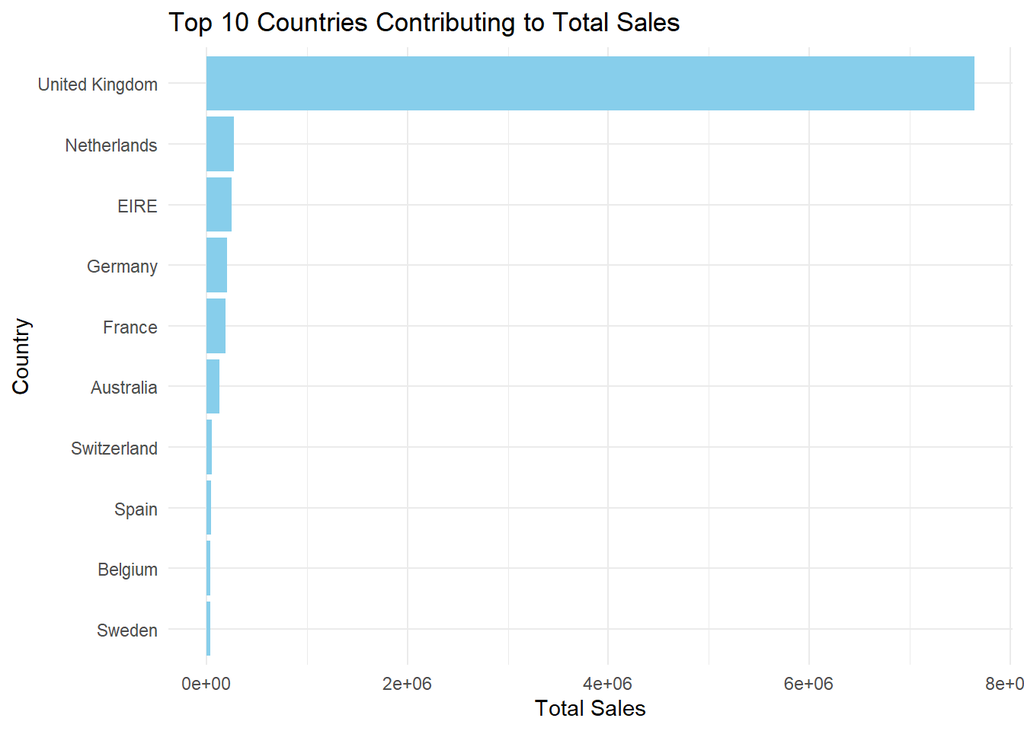

```r
# Bar chart for top 10 countries by sales
top_countries <- country_sales %>%
  top_n(10, TotalSales)

ggplot(top_countries, aes(x = reorder(Country, TotalSales), y = TotalSales)) +
  geom_bar(stat = "identity", fill = "skyblue") +
  coord_flip() +
  labs(
    title = "Top 10 Countries Contributing to Total Sales",
    x = "Country",
    y = "Total Sales"
  ) +
  theme_minimal()
```

```r
#Observation: United Kingdom is leading in terms of overall sales

# Find the top products purchased in each country
unique_behaviors <- data %>%
  group_by(Country, Description) %>%
  summarise(TotalQuantity = sum(Quantity, na.rm = TRUE)) %>%
  top_n(1, TotalQuantity) %>%
  arrange(Country)
# View results
print(unique_behaviors, n = 100)
```

```
## # A tibble: 61 × 3
## # Groups:   Country [38]
##    Country              Description                         TotalQuantity
##    <chr>                <chr>                                       <dbl>
##  1 Australia            MINI PAINT SET VINTAGE                       2916
##  2 Austria              SET 12 KIDS COLOUR  CHALK STICKS              288
##  3 Bahrain              ICE CREAM SUNDAE LIP GLOSS                     96
##  4 Belgium              PACK OF 72 RETROSPOT CAKE CASES               480
##  5 Brazil               DOLLY GIRL LUNCH BOX                           24
##  6 Brazil               GREEN REGENCY TEACUP AND SAUCER                24
##  7 Brazil               PINK REGENCY TEACUP AND SAUCER                 24
##  8 Brazil               ROSES REGENCY TEACUP AND SAUCER                24
##  9 Brazil               SET OF 4 PANTRY JELLY MOULDS                   24
## 10 Brazil               SET OF 6 SPICE TINS PANTRY DESIGN              24
## 11 Brazil               SET/3 RED GINGHAM ROSE STORAGE BOX             24
```

[output cut: 50 more lines]

```r
# Calculate average basket size for each country
basket_size_by_country <- data %>%
  group_by(Country) %>%
  summarise(AverageBasketSize = mean(Quantity, na.rm = TRUE)) %>%
  arrange(desc(AverageBasketSize))

# View results
print(head(basket_size_by_country, 10))
```

```
## # A tibble: 10 × 2
##    Country        AverageBasketSize
##    <chr>                      <dbl>
##  1 Netherlands                 84.9
##  2 Sweden                      79.3
##  3 Japan                       71.8
##  4 Australia                   68.2
##  5 Singapore                   23.5
##  6 Czech Republic              22.7
##  7 Denmark                     21.4
##  8 Canada                      18.9
##  9 Lithuania                   18.7
## 10 EIRE                        17.7
```

```r
# Transactions per customer by country
frequency_by_country <- data %>%
  group_by(Country, CustomerID) %>%
  summarise(TotalTransactions = n()) %>%
  summarise(AverageTransactionsPerCustomer = mean(TotalTransactions, na.rm = TRUE)) %>%
  arrange(desc(AverageTransactionsPerCustomer))
# View results
print(head(frequency_by_country, 10))
```

```
## # A tibble: 10 × 2
##    Country        AverageTransactionsPerCustomer
##    <chr>                                   <dbl>
##  1 EIRE                                   1885.
##  2 Hong Kong                               264
##  3 Netherlands                             252.
##  4 Singapore                               213
##  5 Iceland                                 162
##  6 Australia                               133.
##  7 United Kingdom                          114.
##  8 Norway                                  101.
##  9 Germany                                  94.0
## 10 France                                   92.8
```

```r
# 4.How do cancellations impact overall sales trends?
# Identify and Separate Canceled Transactions
#Add a column to indicate whether a transaction is a cancellation
data <- data %>%
  mutate(Cancelled = if_else(str_detect(InvoiceNo, "^C"), "Yes", "No"))

# Calculate sales for cancellations and non-cancellations
sales_summary <- data %>%
  mutate(Sales = Quantity * UnitPrice) %>%  #Calculate sales per row
  group_by(Cancelled) %>%
  summarise(TotalSales = sum(Sales, na.rm = TRUE),
    TotalTransactions = n()
  )

# View the summary
print(sales_summary)
```

```
## # A tibble: 2 × 3
##   Cancelled TotalSales TotalTransactions
##   <chr>          <dbl>             <int>
## 1 No          9726507.            481303
## 2 Yes         -627409.              8578
```

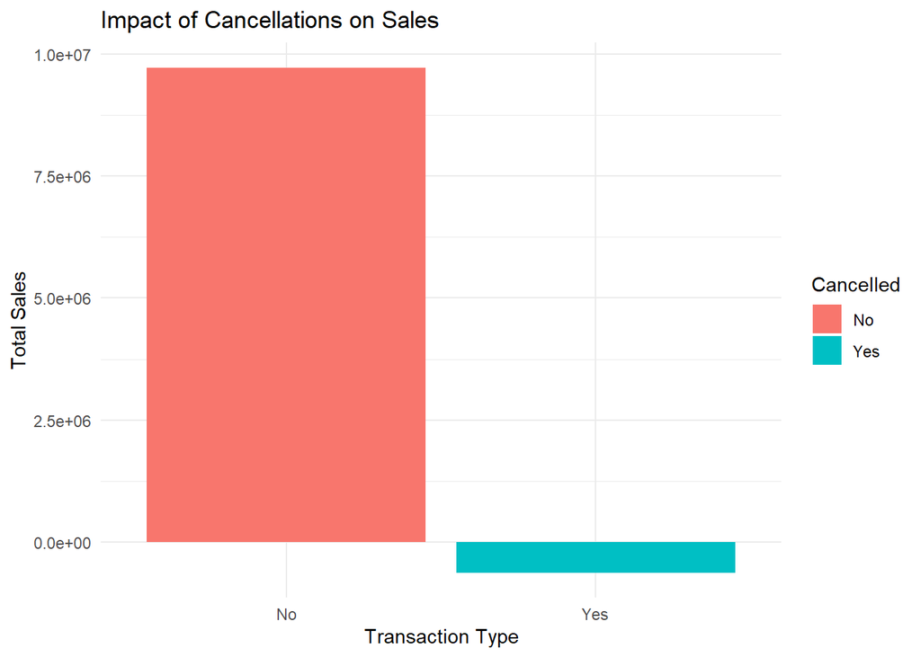

```r
# Bar chart to show cancellations vs non-cancellations
ggplot(sales_summary, aes(x = Cancelled, y = TotalSales, fill = Cancelled)) +
  geom_bar(stat = "identity") +
  labs(
    title = "Impact of Cancellations on Sales",
    x = "Transaction Type",
    y = "Total Sales"
  ) +
  theme_minimal()
```

```r
# Extract the month and year from InvoiceDate
data <- data %>%
  mutate(
    InvoiceDate = as.Date(InvoiceDate),
    Month = format(InvoiceDate, "%Y-%m")
  )

percent_canceled <- sales_summary %>%
  filter(Cancelled == "Yes") %>%
  summarise(PercentLost = (TotalSales / sum(sales_summary$TotalSales)) * 100)

print(percent_canceled)
```

```
## # A tibble: 1 × 1
##   PercentLost
##         <dbl>
## 1       -6.90
```

```r
# Aggregate sales by month and cancellation status
monthly_sales <- data %>%
  mutate(Sales = Quantity * UnitPrice) %>%
  group_by(Month, Cancelled) %>%
  summarise(TotalSales = sum(Sales, na.rm = TRUE)) %>%
  ungroup()
```

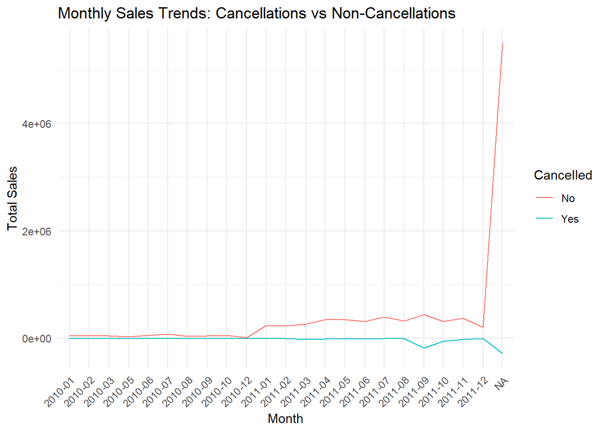

```r
# Line plot to compare monthly trends
ggplot(monthly_sales, aes(x = Month, y = TotalSales, color = Cancelled, group = Cancelled)) +
  geom_line() +
  labs(
    title = "Monthly Sales Trends: Cancellations vs Non-Cancellations",
    x = "Month",
    y = "Total Sales"
  ) +
  theme_minimal() +
  theme(axis.text.x = element_text(angle = 45, hjust = 1))
```

```r
percent_canceled <- sales_summary %>%
  filter(Cancelled == "Yes") %>%
  summarise(PercentLost = (TotalSales / sum(sales_summary$TotalSales)) * 100)

print(percent_canceled)
```

```
## # A tibble: 1 × 1
##   PercentLost
##         <dbl>
## 1       -6.90
```

```r
# Calculate total canceled quantities by taking the absolute value of Quantity
top_canceled_products <- data %>%
  filter(Cancelled == "Yes") %>%
  group_by(Description) %>%
  summarise(TotalCanceled = sum(abs(Quantity), na.rm = TRUE)) %>%
  arrange(desc(TotalCanceled))

# Display the top 10 canceled products
print(head(top_canceled_products, 10))
```

```
## # A tibble: 10 × 2
##    Description                         TotalCanceled
##    <chr>                                       <dbl>
##  1 PAPER CRAFT , LITTLE BIRDIE                 80995
##  2 MEDIUM CERAMIC TOP STORAGE JAR              74494
##  3 ROTATING SILVER ANGELS T-LIGHT HLDR          9376
##  4 Manual                                       4066
##  5 FAIRY CAKE FLANNEL ASSORTED COLOUR           3150
##  6 PINK BLUE FELT CRAFT TRINKET BOX             2617
##  7 GIN + TONIC DIET METAL SIGN                  2030
##  8 HERB MARKER BASIL                            1527
##  9 FELTCRAFT DOLL MOLLY                         1447
## 10 PAPER POCKET TRAVELING FAN                   1385
```

```r
# Calculate cancellation rate by product, handling TotalQuantity = 0
cancellation_rate_by_product <- data %>%
  group_by(Description) %>%
  summarise(
    TotalQuantity = sum(Quantity, na.rm = TRUE),
    CanceledQuantity = sum(abs(Quantity[Cancelled == "Yes"]), na.rm = TRUE),
    CancellationRate = if_else(sum(Quantity, na.rm = TRUE) == 0, 0, CanceledQuantity / abs(TotalQuantity))
  ) %>%
  arrange(desc(CancellationRate))

# View the top 10 products with the highest cancellation rates
print(head(cancellation_rate_by_product, 10))
```

```
## # A tibble: 10 × 4
##    Description                   TotalQuantity CanceledQuantity CancellationRate
##    <chr>                                 <dbl>            <dbl>            <dbl>
##  1 ROTATING SILVER ANGELS T-LIG…           100             9376            93.8
##  2 MEDIUM CERAMIC TOP STORAGE J…          3539            74494            21.0
##  3 CHALKBOARD KITCHEN ORGANISER              1               10            10
##  4 ROBIN CHRISTMAS CARD                     -2               12             6
##  5 PANTRY CHOPPING BOARD                   208              946             4.55
##  6 3 WICK CHRISTMAS BRIAR CANDLE            -1                4             4
##  7 WOODEN BOX ADVENT CALENDAR               -6               16             2.67
##  8 GOLDIE LOOKING MIRROR                     5               12             2.4
##  9 IVORY CHANDELIER T-LIGHT HOL…           226              432             1.91
## 10 PINK POODLE HANGING DECORATI…            -7               12             1.71
```

```r
cancellation_rate_by_product <- cancellation_rate_by_product %>%
  filter(TotalQuantity != 0)

cancellation_rate_by_product
```

```
## # A tibble: 3,221 × 4
##    Description                   TotalQuantity CanceledQuantity CancellationRate
##    <chr>                                 <dbl>            <dbl>            <dbl>
##  1 ROTATING SILVER ANGELS T-LIG…           100             9376            93.8
##  2 MEDIUM CERAMIC TOP STORAGE J…          3539            74494            21.0
##  3 CHALKBOARD KITCHEN ORGANISER              1               10            10
##  4 ROBIN CHRISTMAS CARD                     -2               12             6
##  5 PANTRY CHOPPING BOARD                   208              946             4.55
##  6 3 WICK CHRISTMAS BRIAR CANDLE            -1                4             4
##  7 WOODEN BOX ADVENT CALENDAR               -6               16             2.67
##  8 GOLDIE LOOKING MIRROR                     5               12             2.4
##  9 IVORY CHANDELIER T-LIGHT HOL…           226              432             1.91
## 10 PINK POODLE HANGING DECORATI…            -7               12             1.71
## # ℹ 3,211 more rows
```

```r
## Summary & Key Takeaways

# Are there any other interesting patterns or anomalies you notice?

# Identifying high spending but low frequency customers
high_spending_customers <- data %>%
  group_by(CustomerID) %>%
  summarise(
    TotalSpent = sum(Quantity * UnitPrice, na.rm = TRUE),
    TotalTransactions = n()
  ) %>%
  filter(TotalTransactions < 5 & TotalSpent > mean(TotalSpent)) %>%
  arrange(desc(TotalSpent))

print(head(high_spending_customers, 10))
```

```
## # A tibble: 4 × 3
##   CustomerID TotalSpent TotalTransactions
##        <dbl>      <dbl>             <int>
## 1      16532      6749.                 4
## 2      15195      3861                  1
## 3      13135      3096                  1
## 4      16308      2560                  4
```

```r
# Identifying outliers in Quantity and UnitPrice
outliers <- data %>%
  filter(Quantity > quantile(Quantity, 0.99) | UnitPrice > quantile(UnitPrice, 0.99)) %>%
  arrange(desc(Quantity))

print(head(outliers, 10))
```

```
## # A tibble: 10 × 13
##    InvoiceNo StockCode Description     Quantity InvoiceDate UnitPrice CustomerID
##    <chr>     <chr>     <chr>              <dbl> <date>          <dbl>      <dbl>
##  1 581483    23843     PAPER CRAFT , …    80995 2011-09-12       2.08      16446
##  2 541431    23166     MEDIUM CERAMIC…    74215 NA               1.04      12346
##  3 578841    84826     ASSTD DESIGN 3…    12540 NA               0         13256
##  4 542504    37413     <NA>                5568 NA               0            NA
##  5 573008    84077     WORLD WAR 2 GL…     4800 NA               0.21      12901
##  6 554868    22197     SMALL POPCORN …     4300 NA               0.72      13135
##  7 544612    22053     EMPIRE DESIGN …     3906 NA               0.82      18087
##  8 560599    18007     ESSENTIAL BALM…     3186 NA               0.06      14609
##  9 540815    21108     FAIRY CAKE FLA…     3114 2011-11-01       2.1       15749
## 10 550461    21108     FAIRY CAKE FLA…     3114 NA               2.1       15749
## # ℹ 6 more variables: Country <chr>, Hour <int>, DayOfWeek <ord>, Year <dbl>,
## #   Cancelled <chr>, Month <chr>
```

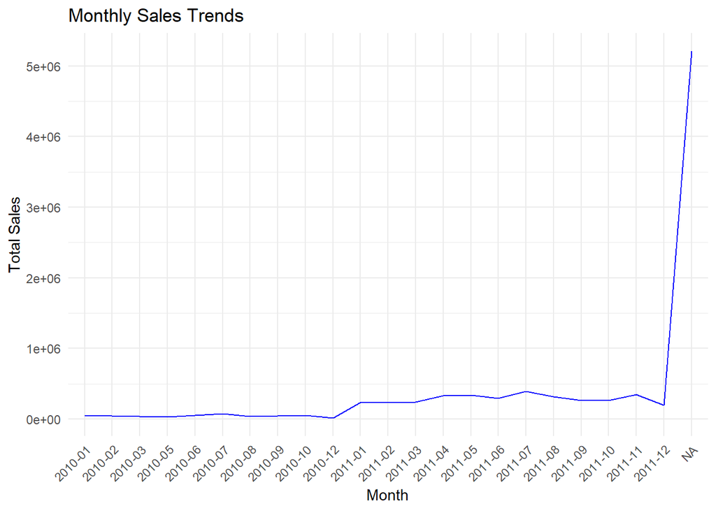

```r
# Time based anomalies
#Analyze sales trends by month
monthly_sales <- data %>%
  mutate(Month = format(as.Date(InvoiceDate), "%Y-%m")) %>%
  group_by(Month) %>%
  summarise(TotalSales = sum(Quantity * UnitPrice, na.rm = TRUE)) %>%
  arrange(Month)

# Visualize sales trends
ggplot(monthly_sales, aes(x = Month, y = TotalSales, group = 1)) +
  geom_line(color = "blue") +
  labs(
    title = "Monthly Sales Trends",
    x = "Month",
    y = "Total Sales"
  ) +
  theme_minimal() +
  theme(axis.text.x = element_text(angle = 45, hjust = 1))
```

```r
# What additional questions or analyses come to mind that could be valuable for the retailer?

#A. Returns and Quality Issues:
top_returned_products <- data %>%
  filter(Cancelled == "Yes") %>%
  group_by(Description) %>%
  summarise(TotalReturns = sum(abs(Quantity), na.rm = TRUE)) %>%
  arrange(desc(TotalReturns))
print(head(top_returned_products, 10))
```

```
## # A tibble: 10 × 2
##    Description                         TotalReturns
##    <chr>                                      <dbl>
##  1 PAPER CRAFT , LITTLE BIRDIE                80995
##  2 MEDIUM CERAMIC TOP STORAGE JAR             74494
##  3 ROTATING SILVER ANGELS T-LIGHT HLDR         9376
##  4 Manual                                      4066
##  5 FAIRY CAKE FLANNEL ASSORTED COLOUR          3150
##  6 PINK BLUE FELT CRAFT TRINKET BOX            2617
##  7 GIN + TONIC DIET METAL SIGN                 2030
##  8 HERB MARKER BASIL                           1527
##  9 FELTCRAFT DOLL MOLLY                        1447
## 10 PAPER POCKET TRAVELING FAN                  1385
```

```r
#B. Revenue Contribution by Product:
product_revenue <- data %>%
  group_by(Description) %>%
  summarise(TotalRevenue = sum(Quantity * UnitPrice, na.rm = TRUE)) %>%
  arrange(desc(TotalRevenue))
print(head(product_revenue, 10))
```

```
## # A tibble: 10 × 2
##    Description                    TotalRevenue
##    <chr>                                 <dbl>
##  1 DOTCOM POSTAGE                      206245.
##  2 REGENCY CAKESTAND 3 TIER            164762.
##  3 PARTY BUNTING                        98303.
##  4 RABBIT NIGHT LIGHT                   66757.
##  5 POSTAGE                              66231.
##  6 PAPER CHAIN KIT 50'S CHRISTMAS       63792.
##  7 ASSORTED COLOUR BIRD ORNAMENT        58960.
##  8 CHILLI LIGHTS                        53768.
##  9 SPOTTY BUNTING                       42065.
## 10 JUMBO BAG PINK POLKADOT              41620.
```

```r
#C. Outlier detection
outliers <- data %>%
  filter(Quantity > quantile(Quantity, 0.99) | UnitPrice > quantile(UnitPrice, 0.99)) %>%
  arrange(desc(Quantity))
print(head(outliers, 20))
```

```
## # A tibble: 20 × 13
##    InvoiceNo StockCode Description     Quantity InvoiceDate UnitPrice CustomerID
##    <chr>     <chr>     <chr>              <dbl> <date>          <dbl>      <dbl>
##  1 581483    23843     PAPER CRAFT , …    80995 2011-09-12       2.08      16446
##  2 541431    23166     MEDIUM CERAMIC…    74215 NA               1.04      12346
##  3 578841    84826     ASSTD DESIGN 3…    12540 NA               0         13256
##  4 542504    37413     <NA>                5568 NA               0            NA
##  5 573008    84077     WORLD WAR 2 GL…     4800 NA               0.21      12901
##  6 554868    22197     SMALL POPCORN …     4300 NA               0.72      13135
##  7 544612    22053     EMPIRE DESIGN …     3906 NA               0.82      18087
##  8 560599    18007     ESSENTIAL BALM…     3186 NA               0.06      14609
##  9 540815    21108     FAIRY CAKE FLA…     3114 2011-11-01       2.1       15749
## 10 550461    21108     FAIRY CAKE FLA…     3114 NA               2.1       15749
## 11 560040    23343     came coded as …     3100 NA               0            NA
## 12 546139    84988     ?                   3000 2011-09-03       0            NA
## 13 573995    16014     SMALL CHINESE …     3000 2011-02-11       0.32      16308
## 14 536830    84077     WORLD WAR 2 GL…     2880 2010-02-12       0.18      16754
## 15 562439    84879     ASSORTED COLOU…     2880 2011-04-08       1.45      12931
## 16 554272    21977     PACK OF 60 PIN…     2700 NA               0.42      12901
## 17 543057    84077     WORLD WAR 2 GL…     2592 2011-03-02       0.21      16333
## 18 539101    22693     GROW A FLYTRAP…     2400 NA               0.94      16029
## 19 543669    22693     GROW A FLYTRAP…     2400 2011-11-02       0.94      16029
## 20 544152    18007     ESSENTIAL BALM…     2400 NA               0.06      14609
## # ℹ 6 more variables: Country <chr>, Hour <int>, DayOfWeek <ord>, Year <dbl>,
## #   Cancelled <chr>, Month <chr>
```

```r
# How might external factors, not present in the dataset, influence the trends you’ve observed?

#1. Spikes in sales due to holidays and seasonal events
#2. Economic conditions (e.g., inflation, unemployment rates) can affect consumer spending habits.
#3. Weather can affect buying patterns, especially for seasonal or weather-specific products.
#4. Competitor promotions or pricing strategies might influence sales.
```